# Logistic Regression Life Expectancy

```r
library(dplyr)
library(ggplot2)
library(tidyverse)
library(xlsx)
library(fpp2)
```

Now that we have imported the files we will begin to import the data and merge them into one large file.

```r
#The dependent variable is life expectancy

life_exp = read.csv("Life_exp_females.csv",header=TRUE)
life_exp <- life_exp[2:122,]
names(life_exp) <- c("Country","Year","Life_exp")
```

```r
str(life_exp)
```

```
'data.frame':   121 obs. of  3 variables:
 $ Country : Factor w/ 122 levels "Afghanistan",..: 1 2 3 4 5 6 7 8 9 10 ...
 $ Year    : Factor w/ 2 levels "2016","Year": 1 1 1 1 1 1 1 1 1 1 ...
 $ Life_exp: Factor w/ 99 levels "53.8","54.4",..: 11 55 46 13 47 67 51 92 87 36 ...
```

```r
life_exp$Life_binary <- 0
life_exp$Life_exp <- as.numeric(as.character(life_exp$Life_exp))
str(life_exp)
```

```
'data.frame':   121 obs. of  4 variables:
 $ Country    : Factor w/ 122 levels "Afghanistan",..: 1 2 3 4 5 6 7 8 9 10 ...
 $ Year       : Factor w/ 2 levels "2016","Year": 1 1 1 1 1 1 1 1 1 1 ...
 $ Life_exp   : num  64.5 78.6 77.4 64.9 77.5 80.3 78.1 84.8 84.2 75.7 ...
 $ Life_binary: num  0 0 0 0 0 0 0 0 0 0 ...
```

```r
#Get median life expectancy
life_exp$life_med <- median(life_exp$Life_exp)

life_exp$Life_binary[life_exp$Life_exp >= 78.5] <- 1
```

Now that we have converted to binary we will visualise the distribution to see how it is balanced.

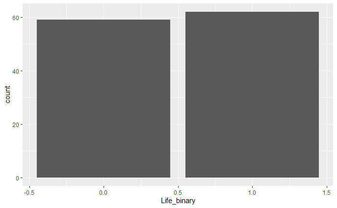

```r
ggplot(data = life_exp, aes(x=Life_binary, fill = Life_binary))+
  geom_bar()
```

Taking the median life expectancy of the countries we can see that the data is balanced.

Now will import the other datasets and merge them into one big dataframe.

```r
#Child mortality
child_mort <- read.csv("Child_mort_female.csv")
child_mort <- child_mort[2:195,]
names(child_mort) <- c("Country","Year","cmortality_rate")
```

```r
#Adult Mortality Rate
adult_mort <- read.csv("adult_mort_rate_females.csv")
adult_mort <- adult_mort[2:184,]
names(adult_mort) <- c("Country","Year","adult_mort_rate")
```

```r
#Drinking_water
drink_services <- read.csv("water_services.csv")
drink_services <- drink_services[3:196,]
names(drink_services) <- c("Country","drinking_services","Year")
```

```r
#HCE
HCE <- read.csv("HCE.csv")
HCE <- HCE[2:188,]
names(HCE) <- c("Country","healthcare_exp","Year")

#Alcohol

alcohol <- read.csv("alcohol.csv")
alcohol <- alcohol[2:194,]
names(alcohol) <- c("Country","Year", "alcohol_consumers")
```

Datsets have been imported so we will merge them into one big dataframe

```r
total <- merge(life_exp, child_mort, by="Country")
total1 <- merge(total, adult_mort, by="Country")
total2 <- merge(total1, drink_services, by="Country")
```

```
column names 㤼㸱Year.x㤼㸲, 㤼㸱Year.y㤼㸲 are duplicated in the result
```

```r
total3 <- merge(total2, HCE, by="Country")
```

```
column names 㤼㸱Year.x㤼㸲, 㤼㸱Year.y㤼㸲 are duplicated in the result
```

```r
total4 <- merge(total3, alcohol, by="Country")
```

```
column names 㤼㸱Year.x㤼㸲, 㤼㸱Year.y㤼㸲, 㤼㸱Year.x㤼㸲, 㤼㸱Year.y㤼㸲 are duplicated in the result
```

```r
#Have some duplications with year but will just select the columns I want

df <- total4[, c("Life_exp","Life_binary","cmortality_rate",
                                "adult_mort_rate","drinking_services",
                                "healthcare_exp","alcohol_consumers")]
```

```r
#Now that I have made the dataframe it is time to inspect it and ensure that it is suitable for logistic regression.

str(df)
```

```
'data.frame':   119 obs. of  7 variables:
 $ Life_exp         : num  64.5 77.4 64.9 77.5 80.3 78.1 84.8 84.2 75.7 79.6 ...
 $ Life_binary      : num  0 0 0 0 1 0 1 1 0 1 ...
 $ cmortality_rate  : Factor w/ 150 levels "1.5","1.7","1.8",..: 101 36 106 107 144 6 45 43 36 122 ...
 $ adult_mort_rate  : Factor w/ 127 levels "100","103","104",..: 49 115 41 3 112 100 85 83 108 89 ...
 $ drinking_services: Factor w/ 52 levels "","100","39",..: 20 45 13 48 50 2 2 2 42 2 ...
 $ healthcare_exp   : num  11 6.6 2.7 4.4 7.5 10 9.2 10.4 6.7 4.9 ...
 $ alcohol_consumers: Factor w/ 165 levels ".","0.1","0.2",..: 4 12 93 96 123 34 156 148 25 84 ...
```

```r
str(df)
```

[output not shown]

```r
summary(logfit)
```

```
Call:
glm(formula = Life_binary ~ cmortality_rate, family = binomial,
    data = df)

Deviance Residuals:
    Min       1Q   Median       3Q      Max
-2.0057  -0.1599   0.3120   0.4330   2.4100

Coefficients:
                Estimate Std. Error z value Pr(>|z|)
(Intercept)      3.48272    0.63160   5.514 3.51e-08 ***
cmortality_rate -0.32298    0.06517  -4.956 7.21e-07 ***
---
Signif. codes:  0 ‘***’ 0.001 ‘**’ 0.01 ‘*’ 0.05 ‘.’ 0.1 ‘ ’ 1

(Dispersion parameter for binomial family taken to be 1)

    Null deviance: 164.893  on 118  degrees of freedom
Residual deviance:  70.829  on 117  degrees of freedom
AIC: 74.829

Number of Fisher Scoring iterations: 7
```

```r
summary(logfit1)
```

```
Call:
glm(formula = Life_binary ~ cmortality_rate + healthcare_exp,
    family = binomial(link = "logit"), data = df1)

Deviance Residuals:
    Min       1Q   Median       3Q      Max
-1.9573  -0.1717   0.2627   0.4299   2.5544

Coefficients:
                Estimate Std. Error z value Pr(>|z|)
(Intercept)      2.23471    1.24754   1.791   0.0732 .
cmortality_rate -0.30407    0.06759  -4.499 6.84e-06 ***
healthcare_exp   0.15671    0.14258   1.099   0.2717
---
Signif. codes:  0 ‘***’ 0.001 ‘**’ 0.01 ‘*’ 0.05 ‘.’ 0.1 ‘ ’ 1

(Dispersion parameter for binomial family taken to be 1)

    Null deviance: 164.893  on 118  degrees of freedom
Residual deviance:  69.555  on 116  degrees of freedom
AIC: 75.555

Number of Fisher Scoring iterations: 7
```

```r
str(df1)
```

[output not shown]

```r
summary(logfit3)
```

```
Call:
glm(formula = Life_binary ~ ., family = binomial, data = df1)

Deviance Residuals:
     Min        1Q    Median        3Q       Max
-1.97009  -0.10127   0.06259   0.21981   1.98544

Coefficients:
                  Estimate Std. Error z value Pr(>|z|)
(Intercept)       -3.41615   10.04918  -0.340  0.73390
cmortality_rate   -0.02566    0.09434  -0.272  0.78566
adult_mort_rate   -0.07592    0.02388  -3.180  0.00147 **
drinking_services  0.09261    0.10114   0.916  0.35983
healthcare_exp    -0.04654    0.14804  -0.314  0.75322
alcohol_consumers  0.05178    0.02452   2.112  0.03470 *
---
Signif. codes:  0 ‘***’ 0.001 ‘**’ 0.01 ‘*’ 0.05 ‘.’ 0.1 ‘ ’ 1

(Dispersion parameter for binomial family taken to be 1)

    Null deviance: 164.893  on 118  degrees of freedom
Residual deviance:  52.285  on 113  degrees of freedom
AIC: 64.285

Number of Fisher Scoring iterations: 8
```

```r
logfit4 <- glm(Life_binary ~.-healthcare_exp,data = df1, family = binomial)
summary(logfit4)
```

[output not shown]

```r
logfit5 <- glm(Life_binary ~.-healthcare_exp-drinking_services,data = df1, family = binomial)
summary(logfit5)
```

[output not shown]

```r
logfit6 <- glm(Life_binary ~.-healthcare_exp-cmortality_rate,data = df1, family = binomial)
summary(logfit6)
```

[output not shown]

```r
str(df_factor)
```

```
'data.frame':   119 obs. of  6 variables:
 $ Life_binary      : Factor w/ 2 levels "0","1": 1 1 1 1 2 1 2 2 1 2 ...
 $ cmortality_rate  : num  47.7 19.6 49.6 5 8.8 10.8 2.9 2.7 19.6 6.2 ...
 $ adult_mort_rate  : num  216 84 202 104 80 65 45 44 76 50 ...
 $ drinking_services: num  64 94 55 97 99 100 100 100 91 100 ...
 $ healthcare_exp   : num  11 6.6 2.7 4.4 7.5 10 9.2 10.4 6.7 4.9 ...
 $ alcohol_consumers: num  0.3 1.5 34.3 36.5 55.7 16.2 70.6 68.9 12.8 3.8 ...
```

```r
summary(logfit7)
```

```
Call:
glm(formula = Life_binary ~ . - healthcare_exp - drinking_services -
    cmortality_rate, family = binomial(link = "logit"), data = df_factor)

Deviance Residuals:
     Min        1Q    Median        3Q       Max
-2.14122  -0.10507   0.05581   0.24257   1.84063

Coefficients:
                  Estimate Std. Error z value Pr(>|z|)
(Intercept)        5.17177    1.55460   3.327 0.000879 ***
adult_mort_rate   -0.08132    0.01986  -4.094 4.23e-05 ***
alcohol_consumers  0.05780    0.01888   3.062 0.002198 **
---
Signif. codes:  0 ‘***’ 0.001 ‘**’ 0.01 ‘*’ 0.05 ‘.’ 0.1 ‘ ’ 1

(Dispersion parameter for binomial family taken to be 1)

    Null deviance: 164.893  on 118  degrees of freedom
Residual deviance:  53.474  on 116  degrees of freedom
AIC: 59.474

Number of Fisher Scoring iterations: 8
```

Now that we have a model with significant p-values we will want to evaulate and interpret it.

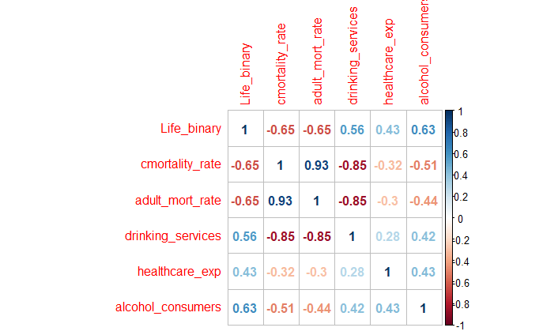

large amount of multicollinearity between adult mortality rate and child mortality rate.

Cox & Snell and Nagelkerke R square

```r
#Cox Snell
#install.packages("fmsb")
#install.packages("blorr") #Used to compute various things like Cox Snell, etc...
library(blorr)
library(fmsb)
library(pscl)

blr_rsq_cox_snell(logfit7) #used to compute the Cox Snell R2
blr_rsq_nagelkerke(logfit7)  #Used to compute the Nagelkerke R2
#NagelkerkeR2(logfit7) #Used to compute the Nagelkerke R2 (different package)
```

[output not shown]

```r
(logfit7)
```

```
Call:  glm(formula = Life_binary ~ . - healthcare_exp - drinking_services -
    cmortality_rate, family = binomial(link = "logit"), data = df_factor)

Coefficients:
      (Intercept)    adult_mort_rate  alcohol_consumers
          5.17177           -0.08132            0.05780

Degrees of Freedom: 118 Total (i.e. Null);  116 Residual
Null Deviance:      164.9
Residual Deviance: 53.47    AIC: 59.47
```

```r
regTermTest(logfit7,"adult_mort_rate")
```

```
Wald test for adult_mort_rate
 in glm(formula = Life_binary ~ . - healthcare_exp - drinking_services -
    cmortality_rate, family = binomial(link = "logit"),
    data = df_factor)
F =  16.76479  on  1  and  116  df: p= 7.8581e-05
```

```r
regTermTest(logfit7, "alcohol_consumers")
```

```
Wald test for alcohol_consumers
 in glm(formula = Life_binary ~ . - healthcare_exp - drinking_services -
    cmortality_rate, family = binomial(link = "logit"),
    data = df_factor)
F =  9.37661  on  1  and  116  df: p= 0.0027319
```

```r
blr_regress(logfit7,odd_conf_limit = TRUE)
```

```
✔ Creating model overview.
✔ Creating response profile.
✔ Extracting maximum likelihood estimates.
✔ Computing odds ratio estimates.
```

[output not shown]

```
✔ Estimating concordant and discordant pairs.

                              Model Overview
---------------------------------------------------------------------------
Data Set       Resp Var    Obs.    Df. Model    Df. Residual    Convergence
---------------------------------------------------------------------------
  data      Life_binary    119        118           116            TRUE
---------------------------------------------------------------------------

                    Response Summary
--------------------------------------------------------
Outcome        Frequency        Outcome        Frequency
--------------------------------------------------------
   0              58               1              61
--------------------------------------------------------

                     Maximum Likelihood Estimates
-----------------------------------------------------------------------
    Parameter        DF    Estimate    Std. Error    z value    Pr(>|z|)
-----------------------------------------------------------------------
   (Intercept)       1      5.1718        1.5546     3.3268       9e-04
 adult_mort_rate     1     -0.0813        0.0199    -4.0945      0.0000
alcohol_consumers    1      0.0578        0.0189     3.0621      0.0022
-----------------------------------------------------------------------

                       Odds Ratio Estimates
------------------------------------------------------------------
     Effects             Estimate            95% Wald Conf. Limit
------------------------------------------------------------------
 adult_mort_rate          0.9219           0.8807           0.9530
alcohol_consumers         1.0595           1.0243           1.1051
------------------------------------------------------------------

 Association of Predicted Probabilities and Observed Responses
---------------------------------------------------------------
% Concordant          0.9650          Somers' D        0.9299
% Discordant          0.0350          Gamma            0.9299
% Tied                0.0000          Tau-a            0.4686
Pairs                  3538           c                0.9650
---------------------------------------------------------------
```

```r
blr_confusion_matrix(logfit7, cutoff=0.5,data = df_factor)
```

```
Confusion Matrix and Statistics

          Reference
Prediction  0  1
         0 51  7
         1  7 54

               Accuracy : 0.8824
                 95% CI : (0.8105, 0.9342)
    No Information Rate : 0.5126
    P-Value [Acc > NIR] : <2e-16

                  Kappa : 0.7646

 Mcnemar's Test P-Value : 1

            Sensitivity : 0.8852
            Specificity : 0.8793
         Pos Pred Value : 0.8852
         Neg Pred Value : 0.8793
             Prevalence : 0.5126
         Detection Rate : 0.4538
   Detection Prevalence : 0.5126
      Balanced Accuracy : 0.8823

       'Positive' Class : 1
```

```r
hoslem.test(df1$Life_binary, fitted(logfit7), g=10)
```

```
    Hosmer and Lemeshow goodness of fit (GOF) test

data:  df1$Life_binary, fitted(logfit7)
X-squared = 5.7502, df = 8, p-value = 0.6752
```